# A Look at Data Analysis Tools or Why You Should Learn R

# A Look at Data Analysis Tools

### or Why You Should Learn R

#### Jake Tolbert

##### Director of Data Services

##### Millikin University

# What We’ll Look At Today

1. A comparison of data analysis tools
2. Using the right tool for the job
3. And since the Right Tools is R, the basics of R

# Tool Comparison

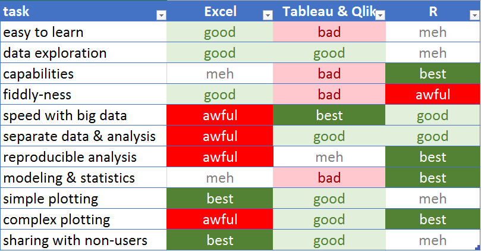

# When The Job Is: Creating Complex Prospect Lists

Use R (or SQL or SAS or some such).

- Data can change underneath, but criteria can be saved.
- QV/Tableau has no way to do complex filtering eg:
  - Theatre majors around Decatur OR $1000 lifetime gifts to Theatre Building

# Pulling A List in R

```r
# imagine I'm connected to a database with databases:
#   - majors_tbl with pidm, major
#   - regions_tbl with pidm, region
#   - donors_tbl with pidm, td_gifts, athletics_gifts, uc_gifts, scholarship_gifts
#   - demographic_tbl with pidm, mailing address, and more ...


# get a list of all Theatre & Dance majors
tdmajors  <- majors_tbl %>%
  filter( major == 'TD'  )

# get a list of everybody around Decatur
arounddecatur  <- regions_tbl %>%
  filter( region == 'DECATUR' )

# get T&D majors around Decatur
td_around_decatur  <- tdmajors %>%
  semi_join(arounddecatur, by = 'pidm') %>%
  distinct(pidm)
```

# Pulling A List (cont.)

```r
# get donors who've given $1000+ to Theatre & Dance building
td_donors  <- donors_tbl %>%
  filter(td_gifts  >= 1000 ) %>%
  distinct(pidm)

#combine both lists then add contact data
my_prospects <- bind_rows( td_around_decatur, td_donors) %>%
  left_join(
    demographic_tbl %>%
        select(pidm, name, address, city, st, zip)
      , by = 'pidm', copy = T
  ) %>%
  collect()
```

# When The Job Is: Exploratory Analysis

- Use QV
  - load data
  - set up list boxes and charts
  - click around
- Use Excel
  - click around
  - run some pivot tables
- R requires a mental model
  - read data in
  - print snippets of the data, use summary stats, environment pane
  - `View(donordata)`
  - `glimpse(donordata)`

# When The Job Is: Creating a Report for Others

1. Build with R Markdown
   - integrate Markdown + R into generated html/pdf.
2. Use QV for dashboards, etc.
3. Dump to Excel and format

# Statisical Analysis

Use R for complex statistical analysis.

# Quick Summary Data

```r
summary(donordata$age)
```

```
##    Min. 1st Qu.  Median    Mean 3rd Qu.    Max.    NA's
##    3.00   32.00   43.00   46.44   59.00   94.00    2163
```

# Quick Summary Data

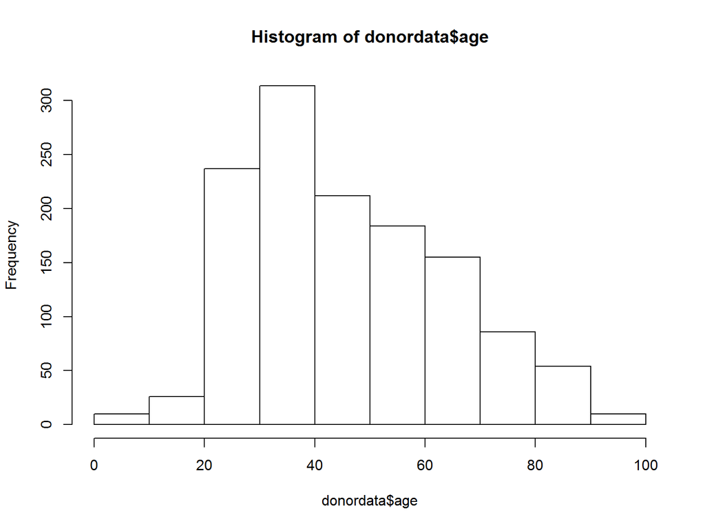

```r
hist(donordata$age)
```

# Quick Summary Data

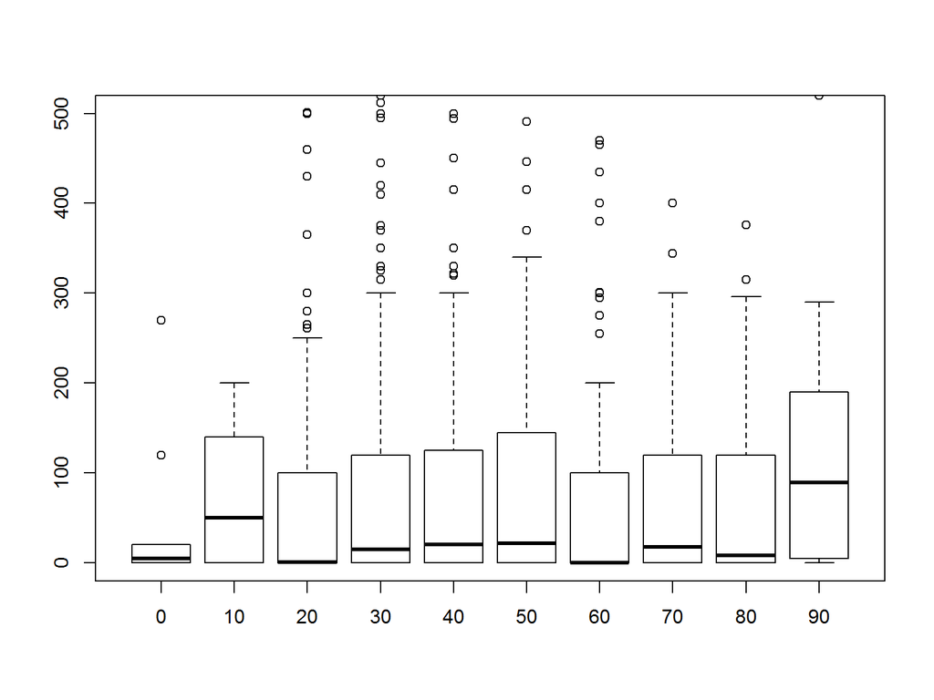

```r
boxplot(donordata$totalgiving ~ donordata$roundedage, ylim = c(0,500) )
```

# More Complex Analytical Tasks

```r
cor.test(donordata$currfygiving, donordata$prevfy1giving)
```

```
##
##  Pearson's product-moment correlation
##
## data:  donordata$currfygiving and donordata$prevfy1giving
## t = 35.976, df = 3449, p-value < 2.2e-16
## alternative hypothesis: true correlation is not equal to 0
## 95 percent confidence interval:
##  0.4976741 0.5462118
## sample estimates:
##       cor
## 0.5223659
```

# More Complex Analytical Tasks

```r
t.test(
    donordata %>% filter(marital_status == 'Married') %>% pull(totalgiving)
  , donordata %>% filter(marital_status != 'Married') %>% pull(totalgiving)
)
```

```
##
##  Welch Two Sample t-test
##
## data:  donordata %>% filter(marital_status == "Married") %>% pull(totalgiving) and donordata %>% filter(marital_status != "Married") %>% pull(totalgiving)
## t = 1.2672, df = 781.72, p-value = 0.2055
## alternative hypothesis: true difference in means is not equal to 0
## 95 percent confidence interval:
##  -855.5105 3971.6408
## sample estimates:
## mean of x mean of y
## 2494.9018  936.8366
```

# When The Job Is: Building Statistical Models

### Use R. It’s the best.

```r
lm_model <- lm(prevfy1giving ~ prevfy2giving + pref_address_type, data = donordata)

rf_model <- randomForest(
                 x = donordata %>% select(prevfy2giving, pref_address_type)
               , y = donordata$prevfy1giving
             )

caret_model <- train(
                x = donordata %>% select(prevfy2giving, pref_address_type)
              , y = donordata$prevfy1giving
              , trControl = trainControl(number = 3)
              )
```

# Build New Data to Predict New Cases

```r
newdata  <- donordata %>%
  select(
      prevfy2giving = prevfy1giving
    , pref_address_type
    , currfygiving
  )


newdata
```

```
##      prevfy2giving pref_address_type currfygiving
## 1                0              HOME            0
## 2                0              HOME            0
## 3                0                              0
## 4                0                              0
## 5                0              HOME            0
## 6                0              HOME            0
## 7                0                              0
## 8                0                              0
## 9                0                              0
## 10               0              HOME            0
## 11               0                              0
## 12               0                              0
## 13               0              HOME            0
## 14               0              HOME            0
```

[output cut: 3437 more lines]

# Predict New Cases

```r
lmpredictions     <- predict(lm_model, newdata)
rfpredictions     <- predict(rf_model, newdata)
caretpredictions  <- predict(caret_model, newdata)

newdata$lmGifts   <- lmpredictions
newdata$rfGifts   <- rfpredictions
newdata$caGifts   <- caretpredictions

newdata %>%
  select(currfygiving, lmGifts, rfGifts, caGifts) %>%
  knitr::kable()
```

| currfygiving | lmGifts | rfGifts | caGifts |
| --- | --- | --- | --- |
| 0 | 42.4000707 | 24.262593 | 17.511190 |
| 0 | 42.4000707 | 24.262593 | 17.511190 |
| 0 | 16.7886146 | 15.552345 | 14.741862 |
| 0 | 16.7886146 | 15.552345 | 14.741862 |
| 0 | 42.4000707 | 24.262593 | 17.511190 |
| 0 | 42.4000707 | 24.262593 | 17.511190 |
| 0 | 16.7886146 | 15.552345 | 14.741862 |
| 0 | 16.7886146 | 15.552345 | 14.741862 |
| 0 | 16.7886146 | 15.552345 | 14.741862 |
| 0 | 42.4000707 | 24.262593 | 17.511190 |
| 0 | 16.7886146 | 15.552345 | 14.741862 |
| 0 | 16.7886146 | 15.552345 | 14.741862 |
| 0 | 42.4000707 | 24.262593 | 17.511190 |
| 0 | 42.4000707 | 24.262593 | 17.511190 |
| 0 | 42.7759488 | 41.506140 | 45.657122 |
| 0 | 42.4000707 | 24.262593 | 17.511190 |
| 0 | 42.4000707 | 24.262593 | 17.511190 |
| 0 | 42.4000707 | 24.262593 | 17.511190 |
| 0 | 42.4000707 | 24.262593 | 17.511190 |
| 0 | 42.4000707 | 24.262593 | 17.511190 |
| 0 | 42.4000707 | 24.262593 | 17.511190 |
| 0 | 42.4000707 | 24.262593 | 17.511190 |
| 0 | 42.4000707 | 24.262593 | 17.511190 |
| 120 | 42.4000707 | 24.262593 | 17.511190 |
| 0 | 42.4000707 | 24.262593 | 17.511190 |
| 0 | 42.4000707 | 24.262593 | 17.511190 |
| 0 | 43.2041741 | 228.373194 | 650.516883 |
| 0 | 42.4000707 | 24.262593 | 17.511190 |
| 0 | 42.4000707 | 24.262593 | 17.511190 |
| 0 | 42.4000707 | 24.262593 | 17.511190 |

[output cut: 3421 more lines]

# Using R

- begin in an interactive environment
- slide gradually into programming
- use RStudio

# Use the Tidyverse

- a series of libraries with an opinionated way about how you should work in R
- a library (or package) is an optional set of functions

[figure not shown]

# Load Packages in Every Script

My scripts almost always begin like this:

```r
# libraries -------------------------------------------

library(tidyverse)
library(magrittr)
library(lubridate)
library(readxl)
library(muadc)
library(fundRaising)

# now do actual real work ----------------------------
```

# Everything in R Is Based on Functions

- a function is a command that does something, a verb so to speak
  - `sum( some_numbers, na.rm = T)`
- store results in another object like this:
  - `new_object <- sum( some_numbers, na.rm = T)`

# Base R - Use Nested Functions

```r
fullstory  <- bop(
  scoop(
    hop(foo_foo, through = forest),
    up = field_mice
  ),
  on = head
)

# or the same thing, but even more poorly formatted
fullstory  <- bop(scoop(hop(foo_foo, through=forest), up=field_mice), on = head)
```

- really hard to read
- nobody thinks this way (so it’s hard to write this way)

# Lots of Little Steps, Saving New Objects

```r
foo_foo_1 <- hop(  foo_foo  , through = forest)
foo_foo_2 <- scoop(foo_foo_1, up = field_mice)
fullstory <- bop(  foo_foo_2, on = head)
```

- not terrible
- but terribly messy

# Lots of Little Steps, Overwriting Each Time

```r
foo_foo   <- hop(  foo_foo, through = forest)
foo_foo   <- scoop(foo_foo, up = field_mice)
foo_foo   <- bop(  foo_foo, on = head)
fullstory <- foo_foo
```

- even better
- but debugging `scoop()` is a royal pain
- and if the original foo_foo was a 200MB csv, you’ll have to read it in again

# Use the Pipe

```r
fullstory  <- foo_foo %>%
  hop(through = forest) %>%
  scoop(up = field_mouse) %>%
  bop(on = head)
```

- reads the way it happens
- not messy
- simple to debug

# Dplyr’s Verbs

```r
donordata %>%
  mutate(last2yrsgiving = prevfy1giving + prevfy2giving) %>%
  filter(alumnus_ind | totalgiving > 1000 ) %>%
  select(id, totalgiving, last2yrsgiving, alumnus_ind) %>%
  arrange(totalgiving)
```

```
##        id totalgiving last2yrsgiving alumnus_ind
## 1   11776           0              0        TRUE
## 2   15917           0              0        TRUE
## 3   20719           0              0        TRUE
## 4   26546           0              0        TRUE
## 5   25130           0              0        TRUE
## 6   21930           0              0        TRUE
## 7   22951           0              0        TRUE
## 8   26962           0              0        TRUE
## 9   21923           0              0        TRUE
## 10  33055           0              0        TRUE
## 11  15355           0              0        TRUE
## 12  23489           0              0        TRUE
## 13  17036           0              0        TRUE
## 14  23829           0              0        TRUE
```

[output cut: 980 more lines]

Google for “dplyr vignette” for an even better description.

# Pivot Table Verbs

```r
donordata %>%
  group_by(alumnus_ind) %>%
  summarize(
      n_people = n()
    , mean_giving   = mean(totalgiving, na.rm = T)
    , median_giving = median(totalgiving, na.rm = T)
  )
```

```
## # A tibble: 2 x 4
##   alumnus_ind n_people mean_giving median_giving
##   <lgl>          <int>       <dbl>         <dbl>
## 1 FALSE           2636       1415.            25
## 2 TRUE             815        676.            25
```

# Fancy Plotting - Contact Reports

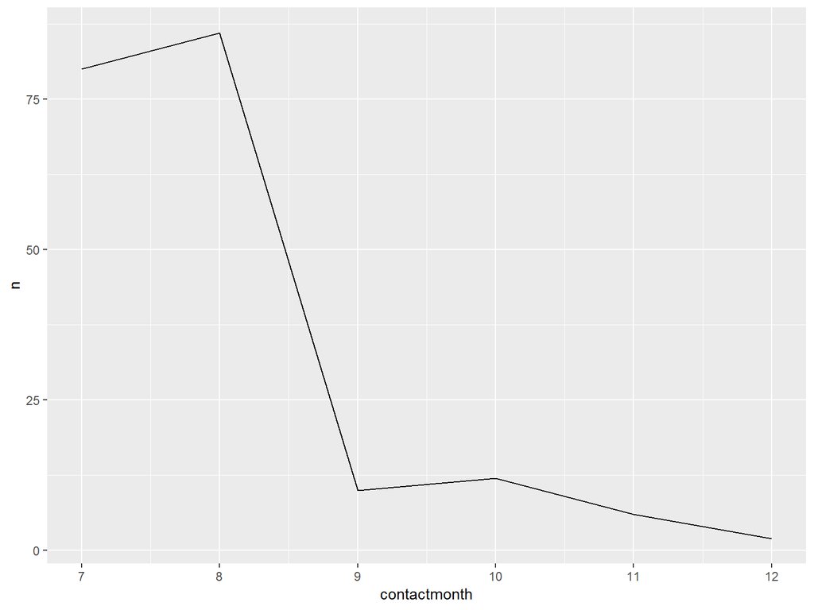

```r
fundRaising::contact_data %>%
  count(contactmonth = month(mdy(Date))) %>%
  ggplot(aes(x = contactmonth)) +
    geom_line(aes(y = n))
```

# Fancy Plotting - Contact Reports by Staff Member

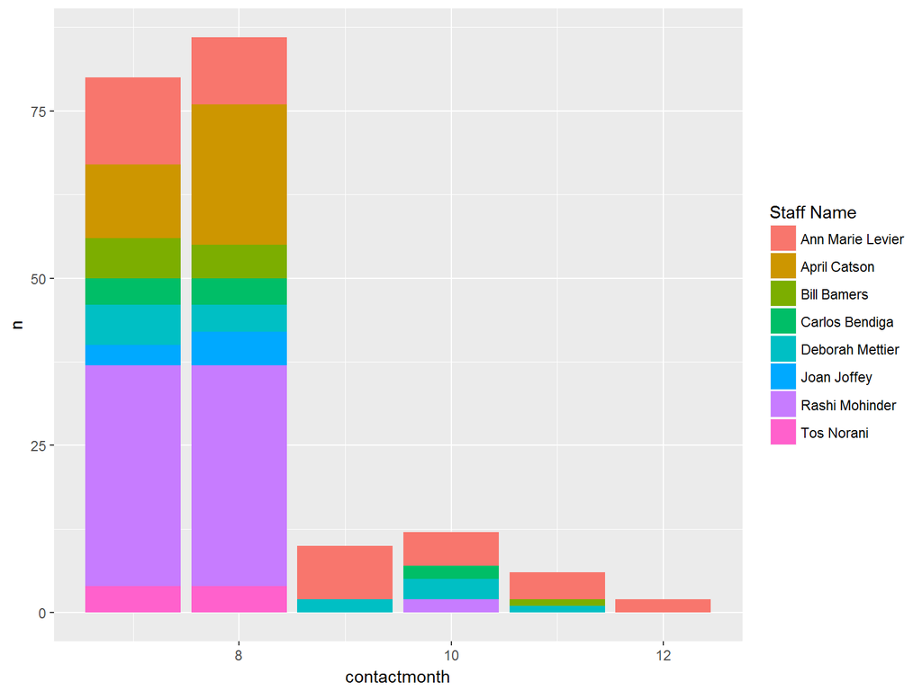

```r
fundRaising::contact_data %>%
  count(contactmonth = month(mdy(Date)), `Staff Name`) %>%
  ggplot(aes(x = contactmonth, fill = `Staff Name`)) +
    geom_col(aes(y=n))
```

# Fancy Plotting - Contat Reports by Staff Member

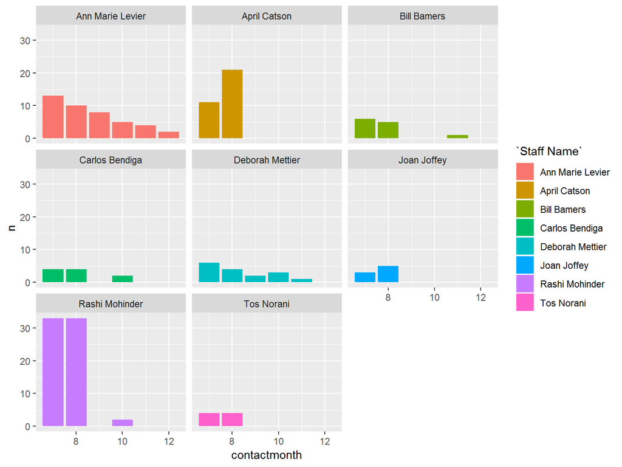

```r
fundRaising::contact_data %>%
  count(contactmonth = month(mdy(Date)), `Staff Name`) %>%
  ggplot(aes(x = contactmonth, fill = `Staff Name`)) +
    geom_col(aes(y = n)) +
    facet_wrap(~`Staff Name`)
```

# Lots More Code Examples on Github

- https://github.com/crazybilly/airline-is470-class
  - clone the repo to your desktop and open airline-project.Rproj
  - the fundraising version of this presentation is named “apra-presentation.Rmd”
- documentation in Rmd/html files
- code examples in R files
- https://github.com/crazybilly/fundRaising
  - an R package designed for fundraising analytics
  - sample data sets are available here